# Tarea: JAGS

### 1. Inferencia de dos proporciones binomiales

Consideramos la situación en la que nos interesa estudiar dos proporciones $\theta_1$ y $\theta_2$ correspondientes a dos grupos, este es el ejemplo que vimos en clase con distribuciones conjugadas, Metropolis y Gibbs.

Ahora implementalo en JAGS:

- Asigna una distribución inicial Beta(3, 3) a cada una de las proporciones (vas a suponer independencia de nuestras creencias iniciales).
- Las observaciones están dadas por el siguiente `data.frame`, consisten en el resultado de 14 lanzamientos, 7 de cada moneda, en la primera observamos 5 águilas y en la segunda 2.

```r
library(dplyr)

observaciones <- data_frame(
    moneda = c(rep(1, 7), rep(2, 7)),
    x = c(rep(0, 2), rep(1, 5), rep(0, 5), rep(1, 2))
    )
```

- Genera 3 cadenas y realiza diagnósticos de convergencia, recuerda considerar la etapa de calentamiento.
- Realiza intervalos de confianza para cada proporción binomial, y para la diferencia de las proporciones.

Tip:

El siguiente código especifica el modelo, debes sustituir las `X` con los valores de acuerdo a tu script.

```r
library(R2jags)

# N: número de volados (total), M: número de monedas
modelo_1.bugs <-
'
model{
    for(i in 1:N){
        x[i] ~ dbern(theta[coin[i]])
    }
    # inicial
    for(m in 1:nCoins){
        theta[m] ~ dbeta(3, 3)
    }
}
'
```

```r
cat(modelo_1.bugs, file = 'modelo_1.bugs')


jags_fit <- jags(
  model.file = "modelo_1.bugs",    # modelo de JAGS
  #inits = jags.inits,   # valores iniciales
  data = list(x = observaciones$x, coin = observaciones$moneda, nCoins = 2,  N = 14),    # lista con los datos
  parameters.to.save = c("theta"),  # parámetros por guardar
  n.chains = 3,   # número de cadenas
  n.iter = 10000,    # número de pasos
  n.burnin = 1000   # calentamiento de la cadena
  )
```

```
## module glm loaded
```

```r
head(jags_fit$BUGSoutput$summary)
```

```
##                mean        sd      2.5%        25%        50%        75%
## deviance 18.3465105 1.4624598 16.795627 17.2663673 17.9249062 19.0117492
## theta[1]  0.6136297 0.1283597  0.358000  0.5256536  0.6153716  0.7070677
## theta[2]  0.3869608 0.1264691  0.158464  0.2952303  0.3816425  0.4758665
##               97.5%     Rhat n.eff
## deviance 22.3247673 1.001302  2500
## theta[1]  0.8525384 1.001079  3000
## theta[2]  0.6397107 1.000696  3000
```

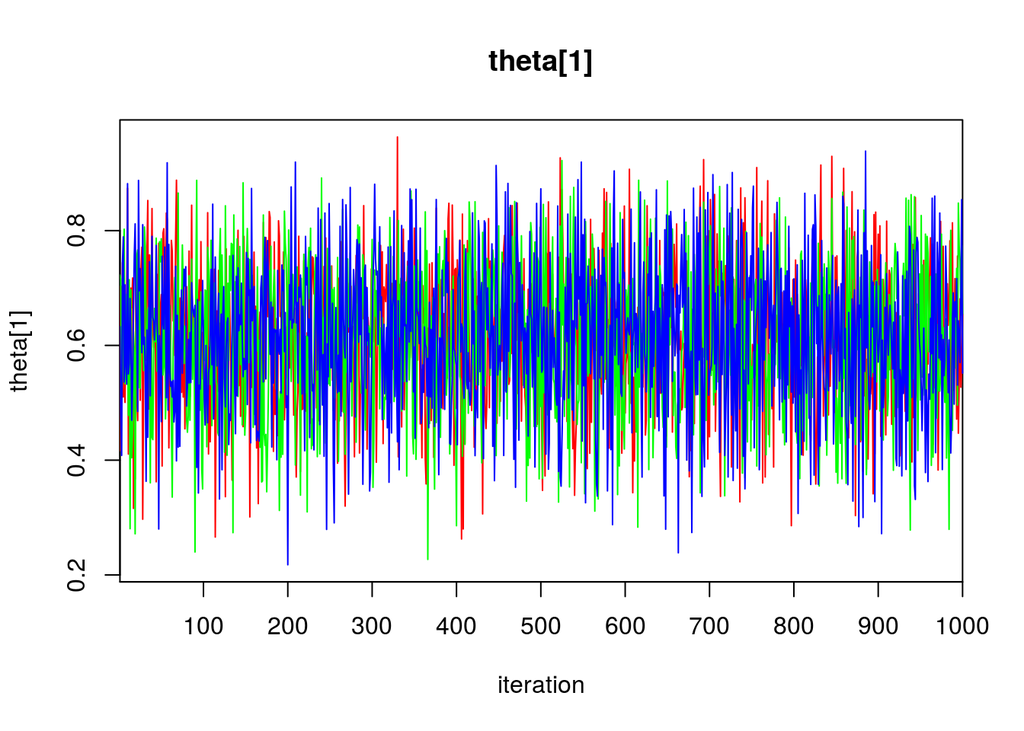

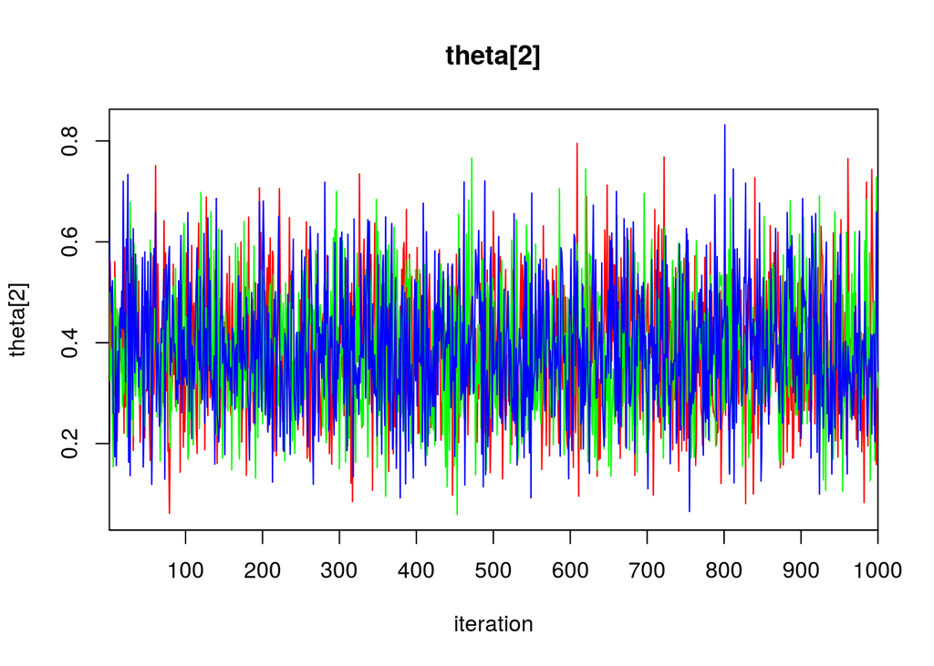

```r
traceplot(jags_fit, varname = c("kappa", "mu", "theta"))
```

Intervalos de confianza:

```r
ICthetas<-apply(jags_fit$BUGSoutput$sims.list$theta,2,quantile,probs = c(0.025, 0.975))

ICthetas
```

```
##            [,1]      [,2]
## 2.5%  0.3580000 0.1584640
## 97.5% 0.8525384 0.6397107
```

### 2. Regresión

Implementaremos un modelo de regresión en JAGS, la base de datos que usaremos contiene información de mediciones de radón (activity) y del suelo en el que se hicieron las mediciones (floor = 0 casas con sótano, floor = 1 casas sin sótano), las mediciones corresponden a 919 hogares muestreados de 85 condados de Minnesota. El objetivo es construir un modelo de regresión en el que la medición de radón es la variable dependiente y el tipo de suelo es la covariable.

El modelo es como sigue:

$$y_i \sim N(\alpha + \beta x_i, \sigma^2)$$

La distribuciones iniciales que usaremos son:

```r
modelo_regresion.bugs <-
'
model{
  for(i in 1 : n) {
    y[i] ~ dnorm(y.hat[i], tau.y)
    y.hat[i] <- a + b * x[i]
  }
  a ~ dnorm(0, 0.001)
  b ~ dnorm(0, 0.001)
  tau.y <- pow(sigma.y, -2)
  sigma.y ~ dunif(0, 100)
}
'
cat(modelo_regresion.bugs, file = 'modelo_regresion.bugs')

### Radon
load("radon.Rdata")

# Iniciamos preparando los datos para el análisis, trabajaremos en
# escala logarítmica, hay algunos casos con medición cero, para éstos
# hacemos una pequeña correción redondeándolos a 0.1.
y <- log(ifelse (radon.2$activity == 0, 0.1, radon.2$activity))

# jags
data_radon <- list(n = nrow(radon.2), y = y, x = radon.2$floor)

inits_radon <- function(){
  list(a = rnorm(1),
  b = rnorm(1),
  sigma.y = runif(1))}

parameters_radon <- c("a", "b", "sigma.y")
```

- El ejercicio consiste en que definas número de cadenas, número de iteraciones y etapa de calentamiento en la siguiente instrucción. Asegurate de alcanzar convergencia y describe los diagnósticos que utilizaste para concluir que se convergió a la distribución posterior.

```r
jags_radon <- jags(
  data = data_radon,
  inits= inits_radon,
  parameters.to.save = parameters_radon,
  model.file = "modelo_regresion.bugs",
   n.chains = 3,   # número de cadenas
  n.iter = 50000,    # número de pasos
  n.burnin = 500, # calentamiento de la cadena
  n.thin = 1)
```

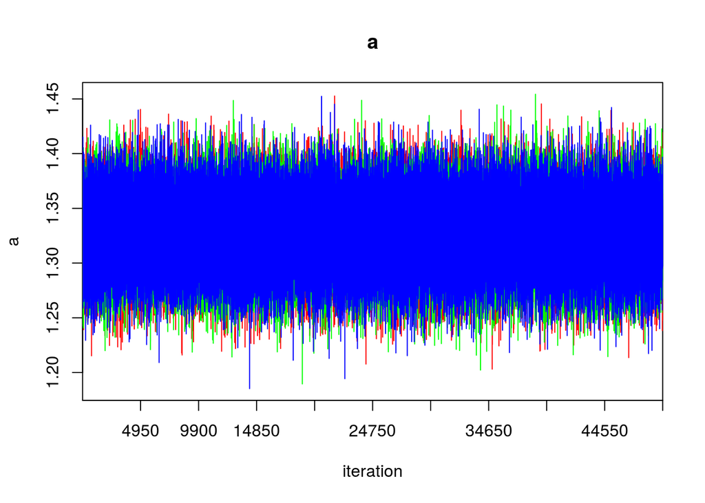

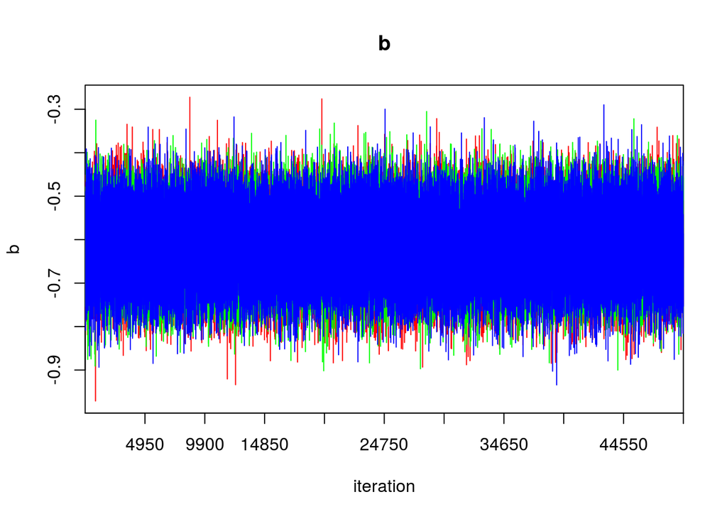

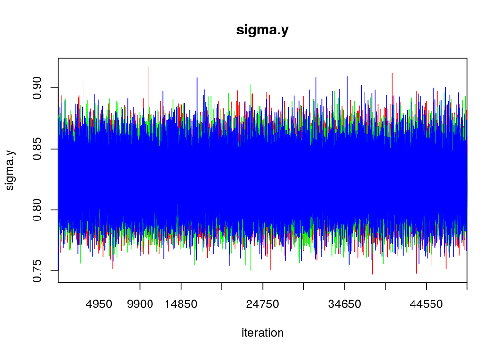

```r
traceplot(jags_radon, varname = c("a", "b", "sigma.y"))
```

- El modelo anterior ignora la variación en los niveles de radón entre los condados. Modifica el modelo para permitir variación, es decir, el modelo será (modelo de unidades independientes):

$$y_i \sim N(\alpha_{j[i]} + \beta x_i, \sigma_y^2)$$

```r
mod_county.bugs<-'
  model {
for(i in 1:919) {
y[i] ~ dnorm(beta[county[i]], sigma^(-2))
}
for(j in 1:85) {
beta[j] ~ dnorm(mu, sigma.b^(-2))
}
mu ~ dnorm(0, 0.0001)
sigma ~ dunif(0, 100)
sigma.b ~ dunif(0, 100)

  }
'
```

```r
data_radonx <- list(n = nrow(radon.2), y = y, county = radon.2$county,J=unique(radon.2$county))
cat(mod_county.bugs, file = 'mod_county.bugs')
J=85
r1.inits <- list(beta = rnorm(J), mu = rnorm(1),
sigma = runif(1), sigma.b = runif(1))
#r1.jags <- jags.model("mod_county.bugs", inits = r1.inits,data=data_radonx)
```